# Lab Assignment Seven: Recurrent Network Architectures

Created by the remnants of the **DREAM TEAM**: Josh Hascall and Daniel Ryan.

[figure not shown]

In this lab, you will select a prediction task to perform on your dataset, evaluate a recurrent architecture and tune hyper-parameters. If any part of the assignment is not clear, ask the instructor to clarify.

This report is worth 10% of the final grade. Please upload a report (one per team) with all code used, visualizations, and text in a rendered Jupyter notebook. Any visualizations that cannot be embedded in the notebook, please provide screenshots of the output. The results should be reproducible using your report. Please carefully describe every assumption and every step in your report.

## Dataset Selection

Select a dataset that is text. That is, the dataset should be text data (or a time series sequence). In terms of generalization performance, it is helpful to have a large dataset of similar sized text documents. It is fine to perform binary classification or multi-class classification. The classification can be "many-to-one" or "many-to-many" sequence classification, whichever you feel more comfortable with.

We are using the [Wikipedia Movie Plots](https://www.kaggle.com/datasets/jrobischon/wikipedia-movie-plots) dataset on Kaggle!

This dataset contains data including genre, release year, title, origin, plot, and more for over 35,000 movies.

We will be selecting the top few genres and classifying them based on their plot description using a RNN.

We think this is a fine dataset for this project because the text should be relatively descriptive for our task and movie plots are all about the same length!

## Preparation (3 points total)

[1 points] Define and prepare your class variables. Use proper variable representations (int, float, one-hot, etc.). Use pre-processing methods (as needed). Describe the final dataset that is used for classification/regression (include a description of any newly formed variables you created). Discuss methods of tokenization in your dataset as well as any decisions to force a specific length of sequence.

```python
import pandas as pd
df = pd.read_csv('wiki_movie_plots_deduped.csv', index_col=0)
df.head()
```

| Release Year | Title | Origin/Ethnicity | Director | Cast | Genre | Wiki Page | Plot |
| --- | --- | --- | --- | --- | --- | --- | --- |
| 1901 | Kansas Saloon Smashers | American | Unknown | NaN | unknown | https://en.wikipedia.org/wiki/Kansas_Saloon_Sm... | A bartender is working at a saloon, serving dr... |
| 1901 | Love by the Light of the Moon | American | Unknown | NaN | unknown | https://en.wikipedia.org/wiki/Love_by_the_Ligh... | The moon, painted with a smiling face hangs ov... |
| 1901 | The Martyred Presidents | American | Unknown | NaN | unknown | https://en.wikipedia.org/wiki/The_Martyred_Pre... | The film, just over a minute long, is composed... |
| 1901 | Terrible Teddy, the Grizzly King | American | Unknown | NaN | unknown | https://en.wikipedia.org/wiki/Terrible_Teddy,_... | Lasting just 61 seconds and consisting of two ... |
| 1902 | Jack and the Beanstalk | American | George S. Fleming, Edwin S. Porter | NaN | unknown | https://en.wikipedia.org/wiki/Jack_and_the_Bea... | The earliest known adaptation of the classic f... |

```python
pd.set_option('display.max_rows', None)
df['Genre'].value_counts()
```

```
unknown                                                                              6083
drama                                                                                5964
comedy                                                                               4379
horror                                                                               1167
action                                                                               1098
thriller                                                                              966
romance                                                                               923
western                                                                               865
crime                                                                                 568
adventure                                                                             526
musical                                                                               467
crime drama                                                                           464
romantic comedy                                                                       461
science fiction                                                                       418
film noir                                                                             345
mystery                                                                               310
war                                                                                   273
animation                                                                             264
comedy, drama                                                                         236
sci-fi                                                                                221
family                                                                                217
fantasy                                                                               204
animated                                                                              195
musical comedy                                                                        154
comedy-drama                                                                          137
biography                                                                             136
anime                                                                                 112
suspense                                                                              104
comedy drama                                                                          103
romantic drama                                                                        103
animated short                                                                         91
drama, romance                                                                         86
social                                                                                 82
historical                                                                             77
action thriller                                                                        73
documentary                                                                            73
serial                                                                                 71
world war ii                                                                           70
family drama                                                                           66
war drama                                                                              65
```

[output cut: 2211 more lines]

```
war, science fiction                                                                    1
history, romance                                                                        1
comedy, drama, war                                                                      1
animation, produced by glukoza production                                               1
social comedy                                                                           1
suspense / drama                                                                        1
family, children's film                                                                 1
spoof                                                                                   1
action, family, drama, comedy                                                           1
family/animation                                                                        1
biopic of pioneering american photographer eadweard muybridge                           1
drama, sports (road bicycle racing), comedy-drama                                       1
drama/disaster                                                                          1
musical, romance, thriller                                                              1
Name: Genre, dtype: int64
```

Here are all the genres... Some of them seem like they could fit into larger genres. We think that it makes the most sense, from a class balance perspective, to combine some of the smaller classes that are action into the action Genre and use drama, comedy and action as our three classes to predict.

```python
#Taking genres that are all basically action and turning them into action genre.

df['Genre'].replace(to_replace=['thriller', 'diaster', 'disaster film', 'action-adventure', 'adventure', 'spy', 'war', 'suspense', 'action thriller'],
                    value=['action', 'action', 'action', 'action', 'action', 'action','action', 'action', 'action'],
                    inplace=True)
df.Genre.value_counts()
```

```
unknown                                                                              6083
drama                                                                                5964
comedy                                                                               4379
action                                                                               3083
horror                                                                               1167
romance                                                                               923
western                                                                               865
crime                                                                                 568
musical                                                                               467
crime drama                                                                           464
romantic comedy                                                                       461
science fiction                                                                       418
film noir                                                                             345
mystery                                                                               310
animation                                                                             264
comedy, drama                                                                         236
sci-fi                                                                                221
family                                                                                217
fantasy                                                                               204
animated                                                                              195
musical comedy                                                                        154
comedy-drama                                                                          137
biography                                                                             136
anime                                                                                 112
romantic drama                                                                        103
comedy drama                                                                          103
animated short                                                                         91
drama, romance                                                                         86
social                                                                                 82
historical                                                                             77
documentary                                                                            73
serial                                                                                 71
world war ii                                                                           70
family drama                                                                           66
war drama                                                                              65
drama, crime                                                                           64
comedy, musical                                                                        63
comedy/drama                                                                           62
comedy, romance                                                                        60
romance, drama                                                                         58
```

[output cut: 2203 more lines]

```
kung fu, comedy                                                                         1
prehistoric adventure                                                                   1
youth, romance                                                                          1
action, biography, drama                                                                1
political, drama, crime, mystery                                                        1
adventure fantasy                                                                       1
fantasy/wuxia                                                                           1
korean war                                                                              1
adventure / musical                                                                     1
comedy, love story, drama                                                               1
drama/romance about alzheimer’s disease based on story by alice munro.                  1
martial art / action                                                                    1
sci-fi, teen                                                                            1
historical/drama/action                                                                 1
Name: Genre, dtype: int64
```

```python
df.drop(['Title', 'Origin/Ethnicity', 'Director', 'Cast', 'Wiki Page'], axis=1, inplace=True)
df.info()
```

```
<class 'pandas.core.frame.DataFrame'>
Int64Index: 34886 entries, 1901 to 2017
Data columns (total 2 columns):
 #   Column  Non-Null Count  Dtype
---  ------  --------------  -----
 0   Genre   34886 non-null  object
 1   Plot    34886 non-null  object
dtypes: object(2)
memory usage: 817.6+ KB
```

```python
df = df.loc[(df['Genre'] == 'drama') | (df['Genre'] == 'comedy') | (df['Genre'] == 'action')]
df['Genre'].value_counts()
```

```
drama     5964
comedy    4379
action    3083
Name: Genre, dtype: int64
```

It appears there is still a class imbalance, though much less pronounced. We think that a small number of stratefied folds will be the best way to divide training and testing data. First because the dataset is now relatively small, less than 15,000, and second since we care equally about classifying each of these and this split is not really what we'll see in the real world. More on this below...

```python
from sklearn import preprocessing

label = preprocessing.LabelEncoder()
df['Genre']= label.fit_transform(df['Genre'])
```

We couldn't think of any reason why the tokenizer that was implemented in class with the max len of 1000 words would not work for our prediction task. We are okay in using all the words instead of a few top words given the potential importance of words with relatively low frequency.

We are tokenizing by replacing each word with a unique integer, as was implemented in class, and making our dataset each sequence of tokens 1000 long.

```python
%%time
import numpy as np
from tensorflow import keras
from tensorflow.keras.preprocessing.text import Tokenizer
from tensorflow.keras.preprocessing.sequence import pad_sequences

NUM_TOP_WORDS = None # use entire vocabulary!
MAX_ART_LEN = 1000 # maximum and minimum number of words

#tokenize the text
tokenizer = Tokenizer(num_words=NUM_TOP_WORDS)
tokenizer.fit_on_texts(df.Plot)
# save as sequences with integers replacing words
sequences = tokenizer.texts_to_sequences(df.Plot)

word_index = tokenizer.word_index
NUM_TOP_WORDS = len(word_index) if NUM_TOP_WORDS==None else NUM_TOP_WORDS
top_words = min((len(word_index),NUM_TOP_WORDS))
print('Found %s unique tokens. Distilled to %d top words.' % (len(word_index),top_words))

X = pad_sequences(sequences, maxlen=MAX_ART_LEN)

y_ohe = keras.utils.to_categorical(df.Genre)
print('Shape of data tensor:', X.shape)
print('Shape of label tensor:', y_ohe.shape)
print(np.max(X))
```

```
Found 96971 unique tokens. Distilled to 96971 top words.
Shape of data tensor: (13426, 1000)
Shape of label tensor: (13426, 3)
96971
CPU times: user 5.16 s, sys: 38.5 ms, total: 5.2 s
Wall time: 5.2 s
```

[1 points] Choose and explain what metric(s) you will use to evaluate your algorithm’s performance. You should give a detailed argument for why this (these) metric(s) are appropriate on your data. That is, why is the metric appropriate for the task (e.g., in terms of the business case for the task). Please note: rarely is accuracy the best evaluation metric to use. Think deeply about an appropriate measure of performance.

We believe that the best and most realistic business use case for this dataset would be some type of movie reccomender algorithm. When we receieve the description and title for a new movie to go into our dataset, we are trying to guess the genre that the movie belongs to. This type of a classifier could be used to help us sort movies into reccomender algorithms that give movie watchers reccomendations based on genre. There are a couple things to consider with our evaluation metric:

1. This is a very low stakes task. An incorrect classification of one type to another, especially given the classes we curently are training our model on (drama, comedy, action), should have very low costs to our end user. This is true of false positives and false negatives.
2. While movies fit into genres, it is kind of wrong to say that no movies can fit into two genres. This blurs the importance of precision, we still care about false negatives and don't want to exclude them.

We considered an F1 scoe or using precision, but ultimately we were unconvinced by their main draws in this case. The simplicity and low stakes of our problem makes us more confident that an occam's razor evaluation metric is best.

We know you say accuracy **sucks** but we believe that accuracy is the best for this business case. We think a higher amount of correct predictions, regardless of class, is most valuable to us.

[1 points] Choose the method you will use for dividing your data into training and testing (i.e., are you using Stratified 10-fold cross validation? Shuffle splits? Why?). Explain why your chosen method is appropriate or use more than one method as appropriate. Convince me that your train/test splitting method is a realistic mirroring of how an algorithm would be used in practice.

We suffer from a moderate, not massive, class imbalance, and a somewhat small dataset. In the real world with our dataset, we don't believe that the frequency of action movies to dramas will match that of the dataset, so it is important that each of our models is trained on roughly equally sized classes.

In practice, this algorithm will be used on new movies with novel plots; we don't feel confident, as experts of our data, to say that any genre of new movies will be more or less frequent than any other. To this end, we want to train each segment equally and ensure that the model doesn't suffer from a lack of training data.

Stratefied k-fold shuffle split is the best way to solve these problems and provide a realistic mirroring of how this algorith will be used in the real world.

However, we consider a 10-fold stratefied shuffle split to be redundant, so we are going with three folds. This will allow us to compare folds and see if we are getting the training we desire, or if they're not adding value.

## Modeling (6 points total)

[3 points] Investigate at least two different recurrent network architectures (perhaps LSTM and GRU). Alternatively, you may also choose one recurrent network and one convolutional network. Be sure to use an embedding layer (try to use a pre-trained embedding, if possible). Adjust hyper-parameters of the networks as needed to improve generalization performance (train a total of at least four models). Discuss the performance of each network and compare them.

Similar to your demo in class, we will use the GLoVe pre-trained for our embedding layer to avoid any issues with unfair comparisons. This should also be faster, as we won't have to train our own layer.

Here we show the different classes from our data, since we only used the most common movie genres, the balancing between the number of instances in each class is a little off. Nevertheless, for the purposes of this model and demonstration it should be sufficient.

```
X Shape: (13426, 1000) Label Shape: (13426, 3)
```

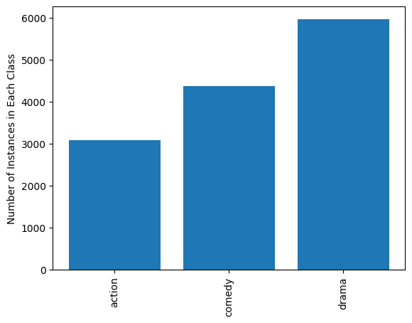

```python
from sklearn.model_selection import train_test_split
from sklearn import metrics as mt
from matplotlib import pyplot as plt
%matplotlib inline

# Split it into train / test subsets
# X_train, X_test, y_train_ohe, y_test_ohe = train_test_split(X, y_ohe, test_size=0.2,
#                                                             stratify=df.Genre,
#                                                             random_state=42)
NUM_CLASSES = 3

# print some stats of the data
print("X Shape:",X.shape, "Label Shape:", y_ohe.shape)
uniq_classes = np.sum(y_ohe,axis=0)
plt.bar(list(range(3)),uniq_classes)
plt.xticks(list(range(3)), ['action', 'comedy', 'drama'], rotation='vertical')
plt.ylabel("Number of Instances in Each Class")
plt.show()
```

Now lets save the word embeddings from glove into an embedding layer.

```python
%%time
EMBED_SIZE = 100
# the embed size should match the file you load glove from
embeddings_index = {}
f = open('glove.6B.100d.txt')
# save key/array pairs of the embeddings
#  the key of the dictionary is the word, the array is the embedding
for line in f:
    values = line.split()
    word = values[0]
    coefs = np.asarray(values[1:], dtype='float32')
    embeddings_index[word] = coefs
f.close()

print('Found %s word vectors.' % len(embeddings_index))

# now fill in the matrix, using the ordering from the
#  keras word tokenizer from before
found_words = 0
embedding_matrix = np.zeros((len(word_index) + 1, EMBED_SIZE))
for word, i in word_index.items():
    embedding_vector = embeddings_index.get(word)
    if embedding_vector is not None:
        # words not found in embedding index will be ALL-ZEROS
        embedding_matrix[i] = embedding_vector
        found_words = found_words+1

print("Embedding Shape:",embedding_matrix.shape, "\n",
      "Total words found:",found_words, "\n",
      "Percentage:",100*found_words/embedding_matrix.shape[0])
```

```
Found 400000 word vectors.
Embedding Shape: (96972, 100)
 Total words found: 65488
 Percentage: 67.53289609371778
CPU times: user 5.15 s, sys: 213 ms, total: 5.36 s
Wall time: 5.37 s
```

67% is not great... But it's higher than what we got in class and should be sufficent!

```python
from tensorflow.keras.layers import Embedding

# save this embedding now
embedding_layer = Embedding(len(word_index) + 1,
                            EMBED_SIZE,
                            weights=[embedding_matrix],# here is the embedding getting saved
                            input_length=MAX_ART_LEN,
                            trainable=False)
```

```python
no_epochs = 15
```

### LSTM Model

Now lets create our LSTM Recurrent neural network!

**Default Hyper-Parameters**

First we will create a function for creating and compiling our model. This will be useful when we run the loop for the stratified shuffle split cross validation.

```python
from tensorflow.keras.models import Sequential
from tensorflow.keras.layers import Dense
from tensorflow.keras.layers import LSTM

def create_lstm_model(opt='rmsprop', neurons=20):
    rnn_lstm = Sequential()
    rnn_lstm.add(embedding_layer)
    rnn_lstm.add(LSTM(neurons,dropout=0.2, recurrent_dropout=0.2))
    rnn_lstm.add(Dense(NUM_CLASSES, activation='sigmoid'))
    rnn_lstm.compile(loss='categorical_crossentropy',
                optimizer=opt,
                metrics=['accuracy'])
    return rnn_lstm

model = create_lstm_model()
print(model.summary())
```

```
Model: "sequential_14"
_________________________________________________________________
 Layer (type)                Output Shape              Param #
=================================================================
 embedding (Embedding)       (None, 1000, 100)         9697200

 lstm_7 (LSTM)               (None, 20)                9680

 dense_13 (Dense)            (None, 3)                 63

=================================================================
Total params: 9,706,943
Trainable params: 9,743
Non-trainable params: 9,697,200
_________________________________________________________________
None
```

Here we created a function for training the model with the number of epochs stated previously. This function then returns the history of the fit function that was called.

```python
def train_model(model, X_train, y_train, X_test, y_test,epochs=no_epochs):
    # history_lstm = []
    tmp = model.fit(X_train, y_train, validation_data=(X_test, y_test),
                       epochs=epochs,
                       batch_size=64)
    # history_lstm.append( tmp )
    return tmp
```

```python
from sklearn.model_selection import StratifiedShuffleSplit
from sklearn.metrics import accuracy_score

sss = StratifiedShuffleSplit(n_splits=3, test_size=0.2,
                             random_state=123)

# we will store the history for each fold, the pick the one with the best performance
lstm_history = []
scores_lstm = []

# idea for saving models:
model_list_lstm = []

for index, (train_idx, test_idx) in enumerate(sss.split(X, y_ohe)):
    print("Training on fold " + str(index+1) + "/3...")
    # Generate batches from indices
    X_train, X_test = X[train_idx], X[test_idx]
    y_train, y_test = y_ohe[train_idx], y_ohe[test_idx]
    fold_history = []

    # Clear model, and create it-- can we save models? look into it pls, maybe save in array or smth, model 1-10
    model = None
    model = create_lstm_model(neurons=10)

    # train model
    tmp = train_model(model, X_train, y_train, X_test, y_test)

    # save model weights for future runs and save history
    model_list_lstm.append(model) #for saving models, dont know if this will work
    fold_history.append(tmp)
    lstm_history.append(fold_history)

    y_hat = model.predict(X_test)
    scores_lstm.append(accuracy_score(np.argmax(y_test,axis=1), np.argmax(y_hat,axis=1)))
```

```
Training on fold 1/3...
Training on fold 2/3...
Training on fold 3/3...
```

Lets see the performance of each of the models to see which one is best.

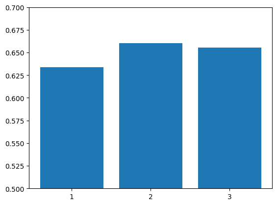

```python
plt.bar([1,2,3],scores_lstm)
plt.xticks([1,2,3],['1','2','3'])
plt.ylim(0.5,0.7)
plt.show()
```

It seems that model 2 performs the best, lets visualize the loss and accuracy for this LSTM model.

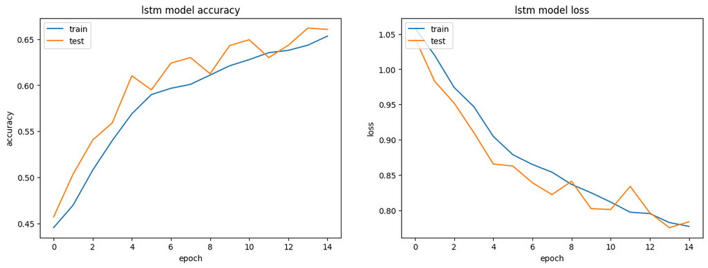

```python
best_fold = 1

# combine all the LSTM history from training together
combined = dict()
for key in ['accuracy','val_accuracy','loss','val_loss']:
    combined[key] = np.hstack([x.history[key] for x in lstm_history[best_fold]])

# summarize history for accuracy
plt.figure(figsize=(15,5))
plt.subplot(121)
plt.plot(combined['accuracy'])
plt.plot(combined['val_accuracy'])
plt.title('lstm model accuracy')
plt.ylabel('accuracy')
plt.xlabel('epoch')
plt.legend(['train', 'test'], loc='upper left')

# summarize history for loss
plt.subplot(122)
plt.plot(combined['loss'])
plt.plot(combined['val_loss'])
plt.title('lstm model loss')
plt.ylabel('loss')
plt.xlabel('epoch')
plt.legend(['train', 'test'], loc='upper left')
plt.show()
```

Unfortunately this model appears to need quite a few more epochs to finish converging. The train and test data appear to be moving together, which doesn't coincide with some models below... Very interesting.

Unlike CNNs which can run in parallel, RNNs, which are modeled sequentially are MUCH slower to run, which we can see here! We suffered from this signifigant increase in run time as we ran fewer epochs than would have been optimal.

Let's see if ROC shows any deviation between our folds or if they essentially trained the same:

```
  perclass_mean_tpr += interp(mean_fpr, fpr, tpr)
  perclass_mean_tpr += interp(mean_fpr, fpr, tpr)
```

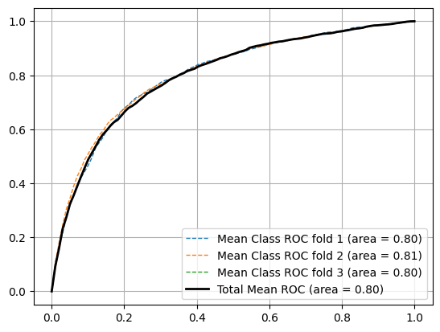

```python
from sklearn.metrics import roc_curve, auc
from scipy import interp
mean_tpr = 0.0
mean_fpr = np.linspace(0, 1, 100)
all_tpr = []
y = np.argmax(y_ohe,axis=1)
for i, (train_idx, test_idx) in enumerate(sss.split(X, y_ohe)):
    y_hat = model_list_lstm[i].predict(X[test_idx])


    perclass_mean_tpr = 0.0
    roc_auc = 0
    classes = np.unique(y[test_idx])

    # get the mean fpr and tpr, per class
    for j in classes:
        fpr, tpr, thresholds = roc_curve(np.argmax(y_ohe[test_idx],axis=1),
                                         np.array(y_hat)[:,j],pos_label=j)
        perclass_mean_tpr += interp(mean_fpr, fpr, tpr)
        perclass_mean_tpr[0] = 0.0
        roc_auc += auc(fpr, tpr)

    perclass_mean_tpr /= len(classes)
    roc_auc /= len(classes)
    mean_tpr += perclass_mean_tpr
    plt.plot(mean_fpr,perclass_mean_tpr,'--',lw=1,label='Mean Class ROC fold %d (area = %0.2f)'
                   % (i+1, roc_auc))

mean_tpr /= 3
mean_auc = auc(mean_fpr, mean_tpr)
plt.plot(mean_fpr,perclass_mean_tpr,'k-',lw=2,label='Total Mean ROC (area = %0.2f)'
                   % (mean_auc))
plt.legend(loc='best')
plt.grid()
```

Cool! Not seeing much difference, though fold 2 sticks out slightly. Now lets create a second LSTM network and see how they compare. Let's try with more nodes and use ADAM

**Varying optimizer and hyperparameters**

For hyperparameter tuning, lets use a different optimizer, Adam, and with a higher number of RNN neurons.

```python
from tensorflow.keras.optimizers import Adam
sss = StratifiedShuffleSplit(n_splits=3, test_size=0.2,
                             random_state=123)

opt = Adam(lr=0.01, epsilon=0.001, clipnorm=1.0)
neurons = 15

# we will store the history for each fold, then average them together
# epoch_history = []
lstm2_history = []
scores_lstm2 = []

# idea for saving models:
model_list_lstm2 = []

for index, (train_idx, test_idx) in enumerate(sss.split(X, y_ohe)):
    print("Training on fold " + str(index+1) + "/3...")
    # Generate batches from indices
    X_train, X_test = X[train_idx], X[test_idx]
    y_train, y_test = y_ohe[train_idx], y_ohe[test_idx]
    fold_history = []

    # Clear model, and create it-- can we save models? look into it pls, maybe save in array or smth, model 1-10
    model = None
    model = create_lstm_model(opt, neurons)

    # train model
    tmp = train_model(model, X_train, y_train, X_test, y_test, epochs=15)

    # save model weights for future runs and save history
    model_list_lstm2.append(model) #for saving models, dont know if this will work

    y_hat = model.predict(X_test)
    scores_lstm2.append(accuracy_score(np.argmax(y_test,axis=1), np.argmax(y_hat,axis=1)))

    fold_history.append(tmp)
    lstm2_history.append(fold_history)
```

```
/shared-libs/python3.9/py/lib/python3.9/site-packages/keras/optimizers/optimizer_v2/adam.py:114: UserWarning: The `lr` argument is deprecated, use `learning_rate` instead.
  super().__init__(name, **kwargs)
Training on fold 1/3...
Epoch 1/15
168/168 [==============================] - 102s 596ms/step - loss: 0.9933 - accuracy: 0.4832 - val_loss: 0.9256 - val_accuracy: 0.5789
Epoch 2/15
168/168 [==============================] - 100s 598ms/step - loss: 0.8823 - accuracy: 0.5841 - val_loss: 0.8303 - val_accuracy: 0.6284
Epoch 3/15
168/168 [==============================] - 101s 600ms/step - loss: 0.8282 - accuracy: 0.6285 - val_loss: 0.8125 - val_accuracy: 0.6392
Epoch 4/15
168/168 [==============================] - 100s 595ms/step - loss: 0.7919 - accuracy: 0.6470 - val_loss: 0.7682 - val_accuracy: 0.6504
Epoch 5/15
168/168 [==============================] - 100s 596ms/step - loss: 0.7720 - accuracy: 0.6488 - val_loss: 0.7666 - val_accuracy: 0.6582
Epoch 6/15
168/168 [==============================] - 101s 602ms/step - loss: 0.7504 - accuracy: 0.6634 - val_loss: 0.7730 - val_accuracy: 0.6642
Epoch 7/15
168/168 [==============================] - 101s 604ms/step - loss: 0.7314 - accuracy: 0.6778 - val_loss: 0.7851 - val_accuracy: 0.6415
Epoch 8/15
168/168 [==============================] - 101s 601ms/step - loss: 0.7158 - accuracy: 0.6887 - val_loss: 0.7615 - val_accuracy: 0.6649
Epoch 9/15
168/168 [==============================] - 102s 604ms/step - loss: 0.7005 - accuracy: 0.6956 - val_loss: 0.7639 - val_accuracy: 0.6549
Epoch 10/15
168/168 [==============================] - 101s 603ms/step - loss: 0.6914 - accuracy: 0.6966 - val_loss: 0.7666 - val_accuracy: 0.6646
Epoch 11/15
168/168 [==============================] - 101s 602ms/step - loss: 0.6837 - accuracy: 0.7025 - val_loss: 0.7887 - val_accuracy: 0.6545
Epoch 12/15
168/168 [==============================] - 101s 602ms/step - loss: 0.6746 - accuracy: 0.7023 - val_loss: 0.7775 - val_accuracy: 0.6534
Epoch 13/15
168/168 [==============================] - 101s 602ms/step - loss: 0.6734 - accuracy: 0.7034 - val_loss: 0.8087 - val_accuracy: 0.6500
Epoch 14/15
168/168 [==============================] - 101s 602ms/step - loss: 0.6616 - accuracy: 0.7139 - val_loss: 0.7949 - val_accuracy: 0.6560
Epoch 15/15
168/168 [==============================] - 101s 603ms/step - loss: 0.6546 - accuracy: 0.7097 - val_loss: 0.7743 - val_accuracy: 0.6608
84/84 [==============================] - 7s 76ms/step
Training on fold 2/3...
Epoch 1/15
168/168 [==============================] - 102s 600ms/step - loss: 1.0125 - accuracy: 0.4801 - val_loss: 0.9250 - val_accuracy: 0.5108
Epoch 2/15
168/168 [==============================] - 101s 599ms/step - loss: 0.9030 - accuracy: 0.5466 - val_loss: 0.8531 - val_accuracy: 0.5931
Epoch 3/15
```

[output cut: 43 more lines]

```
Epoch 9/15
168/168 [==============================] - 100s 594ms/step - loss: 0.7177 - accuracy: 0.6831 - val_loss: 0.7867 - val_accuracy: 0.6497
Epoch 10/15
168/168 [==============================] - 100s 593ms/step - loss: 0.7096 - accuracy: 0.6893 - val_loss: 0.7913 - val_accuracy: 0.6512
Epoch 11/15
168/168 [==============================] - 100s 593ms/step - loss: 0.6954 - accuracy: 0.6997 - val_loss: 0.8002 - val_accuracy: 0.6418
Epoch 12/15
168/168 [==============================] - 100s 594ms/step - loss: 0.6837 - accuracy: 0.7008 - val_loss: 0.7891 - val_accuracy: 0.6378
Epoch 13/15
168/168 [==============================] - 99s 591ms/step - loss: 0.6838 - accuracy: 0.6966 - val_loss: 0.7881 - val_accuracy: 0.6515
Epoch 14/15
168/168 [==============================] - 100s 594ms/step - loss: 0.6761 - accuracy: 0.7022 - val_loss: 0.8013 - val_accuracy: 0.6463
Epoch 15/15
168/168 [==============================] - 100s 593ms/step - loss: 0.6726 - accuracy: 0.7072 - val_loss: 0.7929 - val_accuracy: 0.6523
84/84 [==============================] - 6s 75ms/step
```

Lets see the performance of each of the models to see which one is best.

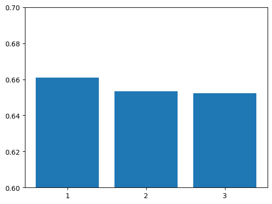

```python
plt.bar([1,2,3],scores_lstm2)
plt.xticks([1,2,3],['1','2','3'])
plt.ylim(0.6,0.7)
plt.show()
```

The accuracy of each of these models seems to be very close, although model one does seem to be a clear winner. This could be statistical noise though. We will run statistical tests on these folds in the section at the bottom of the notebook to see if these folds are actually signifigant from one another.

Now let's visualize the loss and accuracy for our second LSTM model.

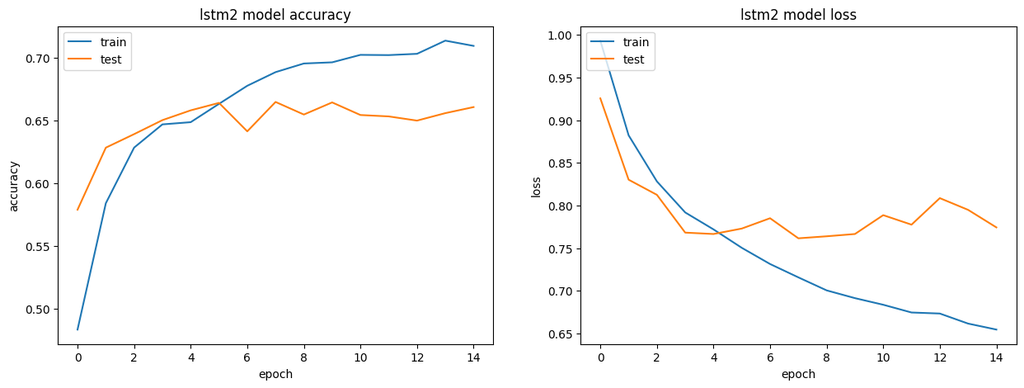

```python
best_fold = 0

# combine all the LSTM history from training together
combined = dict()
for key in ['accuracy','val_accuracy','loss','val_loss']:
    combined[key] = np.hstack([x.history[key] for x in lstm2_history[best_fold]])

# summarize history for accuracy
plt.figure(figsize=(15,5))
plt.subplot(121)
plt.plot(combined['accuracy'])
plt.plot(combined['val_accuracy'])
plt.title('lstm2 model accuracy')
plt.ylabel('accuracy')
plt.xlabel('epoch')
plt.legend(['train', 'test'], loc='upper left')

# summarize history for loss
plt.subplot(122)
plt.plot(combined['loss'])
plt.plot(combined['val_loss'])
plt.title('lstm2 model loss')
plt.ylabel('loss')
plt.xlabel('epoch')
plt.legend(['train', 'test'], loc='upper left')
plt.show()
```

While the training loss keeps decreasing, the testing loss seems to have flattened out. This is interesting and seems to show that overfitting is probably dominating in this model. This can make sense given the small number of nodes we have, but as we'll see, not every model suffers from this. This model definitely has the worst testing performance relative to training.

This model doesn't seem to converge as much as we'd love to see. If we had some more time, a few more epochs would have been preferable. Still, it does not seem that it would have improved our testing loss or accuracy in this case.

```
  perclass_mean_tpr += interp(mean_fpr, fpr, tpr)
  perclass_mean_tpr += interp(mean_fpr, fpr, tpr)
```

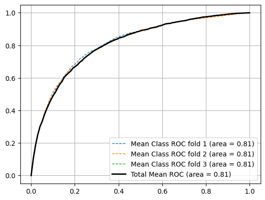

```python
from sklearn.metrics import roc_curve, auc
from scipy import interp
mean_tpr = 0.0
mean_fpr = np.linspace(0, 1, 100)
all_tpr = []
y = np.argmax(y_ohe,axis=1)
for i, (train_idx, test_idx) in enumerate(sss.split(X, y_ohe)):
    y_hat = model_list_lstm2[i].predict(X[test_idx])


    perclass_mean_tpr = 0.0
    roc_auc = 0
    classes = np.unique(y[test_idx])

    # get the mean fpr and tpr, per class
    for j in classes:
        fpr, tpr, thresholds = roc_curve(np.argmax(y_ohe[test_idx],axis=1),
                                         np.array(y_hat)[:,j],pos_label=j)
        perclass_mean_tpr += interp(mean_fpr, fpr, tpr)
        perclass_mean_tpr[0] = 0.0
        roc_auc += auc(fpr, tpr)

    perclass_mean_tpr /= len(classes)
    roc_auc /= len(classes)
    mean_tpr += perclass_mean_tpr
    plt.plot(mean_fpr,perclass_mean_tpr,'--',lw=1,label='Mean Class ROC fold %d (area = %0.2f)'
                   % (i+1, roc_auc))

mean_tpr /= 3
mean_auc = auc(mean_fpr, mean_tpr)
plt.plot(mean_fpr,perclass_mean_tpr,'k-',lw=2,label='Total Mean ROC (area = %0.2f)'
                   % (mean_auc))
plt.legend(loc='best')
plt.grid()
```

Not much deviation here, but the first fold sticks out a little bit. No surprise this is the model we are choosing as our best!

### GRU Model

**Default Hyper-Parameters**

Here is a function for creating the GRU model and compiling it.

```python
from tensorflow.keras.models import Sequential
from tensorflow.keras.layers import Dense
from tensorflow.keras.layers import LSTM,GRU

def create_gru_model(opt='rmsprop', neurons=10):
    rnn_gru = Sequential()
    rnn_gru.add(embedding_layer)
    rnn_gru.add(GRU(neurons,dropout=0.2, recurrent_dropout=0.2))
    rnn_gru.add(Dense(NUM_CLASSES, activation='sigmoid'))
    rnn_gru.compile(loss='categorical_crossentropy',
                optimizer=opt,
                metrics=['accuracy'])
    return rnn_gru

model = create_gru_model()
print(model.summary())
```

```
Model: "sequential_23"
_________________________________________________________________
 Layer (type)                Output Shape              Param #
=================================================================
 embedding (Embedding)       (None, 1000, 100)         9697200

 gru_6 (GRU)                 (None, 10)                3360

 dense_22 (Dense)            (None, 3)                 33

=================================================================
Total params: 9,700,593
Trainable params: 3,393
Non-trainable params: 9,697,200
_________________________________________________________________
None
```

Since we determined that Stratified shuffle split is the best method for our dividing our data, we will use a loop for each fold, similar to what we did for our LSTM model.

```python
from sklearn.model_selection import StratifiedShuffleSplit

sss = StratifiedShuffleSplit(n_splits=3, test_size=0.2,
                             random_state=123)

# we will store the history for each fold, then average them together
gru_history = []
scores_gru = []

# idea for saving models:
model_list_gru = []

for index, (train_idx, test_idx) in enumerate(sss.split(X, y_ohe)):
    print("Training on fold " + str(index+1) + "/3...")
    # Generate batches from indices
    X_train, X_test = X[train_idx], X[test_idx]
    y_train, y_test = y_ohe[train_idx], y_ohe[test_idx]
    fold_history = []

    # Clear model, and create it-- can we save models? look into it pls, maybe save in array or smth, model 1-10
    model = None
    model = create_gru_model(neurons=10)

    # train model
    tmp = train_model(model, X_train, y_train, X_test, y_test,epochs=15)

    # save model weights for future runs and save history
    model_list_gru.append(model) #for saving models, dont know if this will work
    fold_history.append(tmp)
    gru_history.append(fold_history)

    # save scores
    y_hat = model.predict(X_test)
    scores_gru.append(accuracy_score(np.argmax(y_test,axis=1), np.argmax(y_hat,axis=1)))
```

```
Training on fold 1/3...
Training on fold 2/3...
Training on fold 3/3...
```

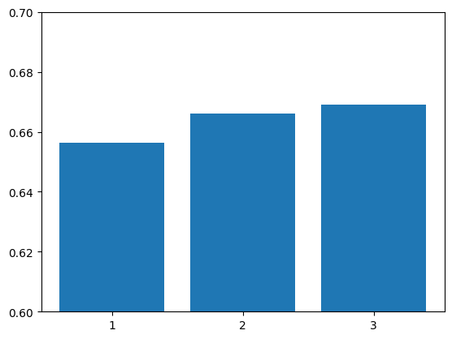

```python
plt.bar([1,2,3],scores_gru)
plt.xticks([1,2,3],['1','2','3'])
plt.ylim(0.6,0.7)
plt.show()
```

Each fold better than the last. Fold 3 is quite a bit better than 1! Let's visualize both the GRU accuracy and loss curves.

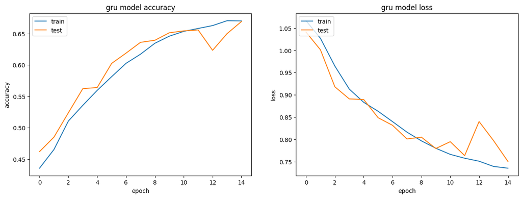

```python
best_fold = 2

# combine all the GRU history from training together
combined = dict()
for key in ['accuracy','val_accuracy','loss','val_loss']:
    combined[key] = np.hstack([x.history[key] for x in gru_history[best_fold]])

# summarize history for accuracy
plt.figure(figsize=(15,5))
plt.subplot(121)
plt.plot(combined['accuracy'])
plt.plot(combined['val_accuracy'])
plt.title('gru model accuracy')
plt.ylabel('accuracy')
plt.xlabel('epoch')
plt.legend(['train', 'test'], loc='upper left')

# summarize history for loss
plt.subplot(122)
plt.plot(combined['loss'])
plt.plot(combined['val_loss'])
plt.title('gru model loss')
plt.ylabel('loss')
plt.xlabel('epoch')
plt.legend(['train', 'test'], loc='upper left')
plt.show()
```

This model appears to be working pretty well (training and testing performing together), and it also seems like it nearly converged!

```
  perclass_mean_tpr += interp(mean_fpr, fpr, tpr)
  perclass_mean_tpr += interp(mean_fpr, fpr, tpr)
```

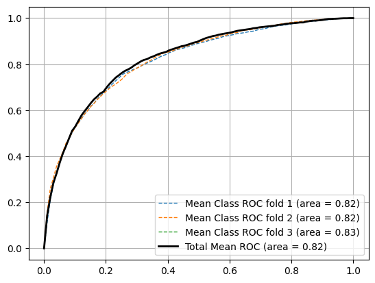

```python
from sklearn.metrics import roc_curve, auc
from scipy import interp
mean_tpr = 0.0
mean_fpr = np.linspace(0, 1, 100)
all_tpr = []
y = np.argmax(y_ohe,axis=1)
for i, (train_idx, test_idx) in enumerate(sss.split(X, y_ohe)):
    y_hat = model_list_gru[i].predict(X[test_idx])


    perclass_mean_tpr = 0.0
    roc_auc = 0
    classes = np.unique(y[test_idx])

    # get the mean fpr and tpr, per class
    for j in classes:
        fpr, tpr, thresholds = roc_curve(np.argmax(y_ohe[test_idx],axis=1),
                                         np.array(y_hat)[:,j],pos_label=j)
        perclass_mean_tpr += interp(mean_fpr, fpr, tpr)
        perclass_mean_tpr[0] = 0.0
        roc_auc += auc(fpr, tpr)

    perclass_mean_tpr /= len(classes)
    roc_auc /= len(classes)
    mean_tpr += perclass_mean_tpr
    plt.plot(mean_fpr,perclass_mean_tpr,'--',lw=1,label='Mean Class ROC fold %d (area = %0.2f)'
                   % (i+1, roc_auc))

mean_tpr /= 3
mean_auc = auc(mean_fpr, mean_tpr)
plt.plot(mean_fpr,perclass_mean_tpr,'k-',lw=2,label='Total Mean ROC (area = %0.2f)'
                   % (mean_auc))
plt.legend(loc='best')
plt.grid()
```

It's hard to tell if there's any meaningful divergence between the models here, but there is definitely more deviation than with the previous models. Fold 3 has a slightly higher area.

**Varying optimizer and hyperparameters**

```python
from sklearn.model_selection import StratifiedShuffleSplit

sss = StratifiedShuffleSplit(n_splits=3, test_size=0.2,
                             random_state=123)

opt = Adam(lr=0.01, epsilon=0.001, clipnorm=1.0)
neurons = 15

# we will store the history for each fold, then average them together
# epoch_history = []
gru2_history = []
scores_gru2 = []

# idea for saving models:
model_list_gru2 = []

for index, (train_idx, test_idx) in enumerate(sss.split(X, y_ohe)):
    print("Training on fold " + str(index+1) + "/3...")
    # Generate batches from indices
    X_train, X_test = X[train_idx], X[test_idx]
    y_train, y_test = y_ohe[train_idx], y_ohe[test_idx]
    fold_history = []

    # Clear model, and create it-- can we save models? look into it pls, maybe save in array or smth, model 1-10
    model = None
    model = create_gru_model(opt, neurons)

    # train model
    tmp = train_model(model, X_train, y_train, X_test, y_test,epochs=15)

    # save model weights for future runs and save history
    model_list_gru2.append(model) #for saving models, dont know if this will work
    # epoch_history.append(tmp)
    fold_history.append(tmp)
    gru2_history.append(fold_history)

    # save scores
    y_hat = model.predict(X_test)
    scores_gru2.append(accuracy_score(np.argmax(y_test,axis=1), np.argmax(y_hat,axis=1)))


# # average all the histories from each fold so we just one one combined history
# gru_history = dict()
# for key in ['accuracy','val_accuracy','loss','val_loss']:
#     gru_history[key] = np.average([x.history[key] for x in epoch_history], axis=0)

# # save histories for this set of epochs
# gru2_history_all.append(gru_history)
```

```
Training on fold 1/3...
Training on fold 2/3...
Training on fold 3/3...
```

Time to choose best fold!

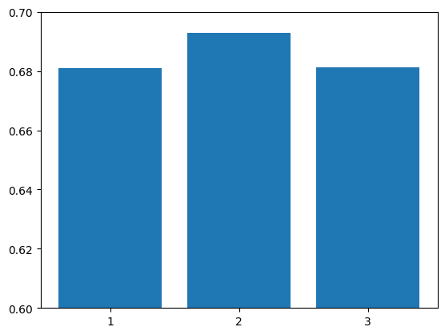

```python
plt.bar([1,2,3],scores_gru2)
plt.xticks([1,2,3],['1','2','3'])
plt.ylim(0.6,0.7)
plt.show()
```

Model 2 here stands out quite a bit!

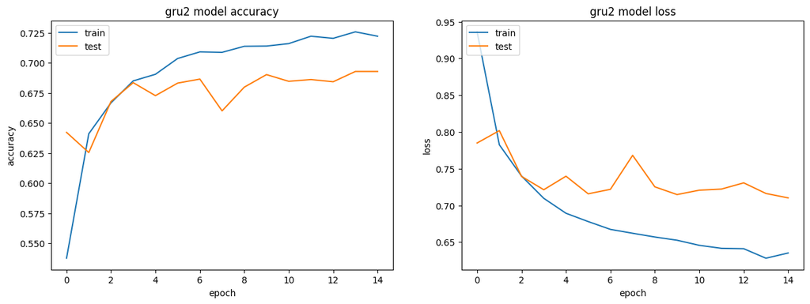

```python
best_fold = 1

# combine all the GRU2 history from training together
combined = dict()
for key in ['accuracy','val_accuracy','loss','val_loss']:
    combined[key] = np.hstack([x.history[key] for x in gru2_history[best_fold]])

# summarize history for accuracy
plt.figure(figsize=(15,5))
plt.subplot(121)
plt.plot(combined['accuracy'])
plt.plot(combined['val_accuracy'])
plt.title('gru2 model accuracy')
plt.ylabel('accuracy')
plt.xlabel('epoch')
plt.legend(['train', 'test'], loc='upper left')

# summarize history for loss
plt.subplot(122)
plt.plot(combined['loss'])
plt.plot(combined['val_loss'])
plt.title('gru2 model loss')
plt.ylabel('loss')
plt.xlabel('epoch')
plt.legend(['train', 'test'], loc='upper left')
plt.show()
```

This model also seemed to have quite a bit of testing data flattening out relative to training data... odd... This interestingly seems to be a product of the number of neurons. Both models with the greater number of neurons had greater variance between their training and testing accuracy and loss.

```
  perclass_mean_tpr += interp(mean_fpr, fpr, tpr)
  perclass_mean_tpr += interp(mean_fpr, fpr, tpr)
```

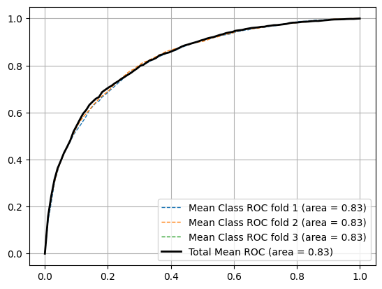

```python
from sklearn.metrics import roc_curve, auc
from scipy import interp
mean_tpr = 0.0
mean_fpr = np.linspace(0, 1, 100)
all_tpr = []
y = np.argmax(y_ohe,axis=1)
for i, (train_idx, test_idx) in enumerate(sss.split(X, y_ohe)):
    y_hat = model_list_gru2[i].predict(X[test_idx])


    perclass_mean_tpr = 0.0
    roc_auc = 0
    classes = np.unique(y[test_idx])

    # get the mean fpr and tpr, per class
    for j in classes:
        fpr, tpr, thresholds = roc_curve(np.argmax(y_ohe[test_idx],axis=1),
                                         np.array(y_hat)[:,j],pos_label=j)
        perclass_mean_tpr += interp(mean_fpr, fpr, tpr)
        perclass_mean_tpr[0] = 0.0
        roc_auc += auc(fpr, tpr)

    perclass_mean_tpr /= len(classes)
    roc_auc /= len(classes)
    mean_tpr += perclass_mean_tpr
    plt.plot(mean_fpr,perclass_mean_tpr,'--',lw=1,label='Mean Class ROC fold %d (area = %0.2f)'
                   % (i+1, roc_auc))

mean_tpr /= 3
mean_auc = auc(mean_fpr, mean_tpr)
plt.plot(mean_fpr,perclass_mean_tpr,'k-',lw=2,label='Total Mean ROC (area = %0.2f)'
                   % (mean_auc))
plt.legend(loc='best')
plt.grid()
```

Just like with the previous models, there doesn't appear to be a major difference in ROC between the folds. We will compare the best models of each of the 4 types below.

```python
#save the models so nothing can break on us!
m_num = 0
for models in [model_list_lstm,model_list_lstm2,model_list_gru,model_list_gru2]:
    m2_num = 0
    for model in models:

        text = "Model"+str(m_num) + str(m2_num)
        model.save('large_data/'+text + '.h5')
        m2_num += 1
    m_num += 1
```

[1 points] Fall 2022 Skip this part of the rubric; You will receive full credit. Using the best RNN parameters and architecture, add a second recurrent chain to your RNN. The input to the second chain should be the output sequence of the first chain. Visualize the performance of training and validation sets versus the training iterations.

**Yay!**

However, if we did wish to do that, all we would have to do is save the outputs of every recurrent cell in a new input vector. This can be done by setting the return_state flag within the model function to **True**. This would then lead the model to return the output state of every cell in the network as a list. Then we would create another RNN layer where we would use this new list as the input! After that, we would put it into the dense layer, similar to before, to get our prediction.

[2 points] Use the method of train/test splitting and evaluation criteria that you argued for at the beginning of the lab. Visualize the results of all the RNNs you trained. Use proper statistical comparison techniques to determine which method(s) is (are) superior.

```python
yhat_lstm = []
yhat_lstm2 = []
yhat_gru = []
yhat_gru2 = []
y_tests = []
models_best = [1,0,2,1] #the best fold for each model, as determined and graphed above

for index, (train_idx, test_idx) in enumerate(sss.split(X, y_ohe)):
    yhat_lstm.append(model_list_lstm[index].predict(X[test_idx]))
    yhat_lstm2.append(model_list_lstm2[index].predict(X[test_idx]))
    yhat_gru.append(model_list_gru[index].predict(X[test_idx]))
    yhat_gru2.append(model_list_gru2[index].predict(X[test_idx]))
    y_tests.append(y_ohe[test_idx])
```

Before we compare each model, we'd like to do mcnemar tests on each fold within our models to see if they are similar or statistically signifigant from one another. Our ROC curves seem to show us that each of our folds within each model are relatively similar to one another, but let's test that here:

```python
from statsmodels.stats.contingency_tables import mcnemar
counter = 0
str_list = ["lstm","lstm2","gru","gru2"]

for model in [yhat_lstm,yhat_lstm2,yhat_gru,yhat_gru2]:
    conf1 = mt.confusion_matrix(np.argmax(model[0],axis=1),np.argmax(model[1],axis=1))
    conf2 = mt.confusion_matrix(np.argmax(model[0],axis=1),np.argmax(model[2],axis=1))
    conf3 = mt.confusion_matrix(np.argmax(model[1],axis=1),np.argmax(model[2],axis=1))

    print("MODEL: " + str_list[counter])
    counter += 1

    print("Fold 1 vs. Fold 2")
    print(mcnemar(conf1, exact=False))
    print(conf)
    print("\n")
    print("Fold 1 vs. Fold 3")
    print(mcnemar(conf2, exact=False))
    print(conf)
    print("\n")
    print("Fold 2 vs. Fold 3")
    print(mcnemar(conf3, exact=False))
    print(conf)
    print("******************************************")
```

```
MODEL: lstm
Fold 1 vs. Fold 2
pvalue      7.020933476451878e-07
statistic   24.609375
[[156 171 247]
 [277 387 574]
 [192 255 427]]


Fold 1 vs. Fold 3
pvalue      0.021756145444375527
statistic   5.265182186234818
[[156 171 247]
 [277 387 574]
 [192 255 427]]


Fold 2 vs. Fold 3
pvalue      0.03118615800010389
statistic   4.642685851318944
[[156 171 247]
 [277 387 574]
 [192 255 427]]
MODEL: lstm2
Fold 1 vs. Fold 2
pvalue      7.020933476451878e-07
statistic   24.609375
[[156 171 247]
 [277 387 574]
 [192 255 427]]


Fold 1 vs. Fold 3
pvalue      0.021756145444375527
statistic   5.265182186234818
[[156 171 247]
 [277 387 574]
 [192 255 427]]


```

[output cut: 37 more lines]

```

Fold 1 vs. Fold 3
pvalue      0.0314190055577459
statistic   4.6299212598425195
[[156 171 247]
 [277 387 574]
 [192 255 427]]


Fold 2 vs. Fold 3
pvalue      0.8659829169079334
statistic   0.028481012658227847
[[156 171 247]
 [277 387 574]
 [192 255 427]]
```

Ok this was quite a bit of output here but it does seem to show something fairly remarkable. Most of the folds are statistically signifigant from one another. We are not entirely sure how to interpret this, or if it's good or not. The good way to say it is we chose the right method of training and testing and splitting our data. The bad way to say it is that our models may not have converged yet so there's dispersion in the performance of each one that would be smoothed out if we had more time.

We can now start to compare the best of each of our models against one another to determine which is the strongest and if they're actually different. Let's start with plotting the losses and accuracies of the models against one another:

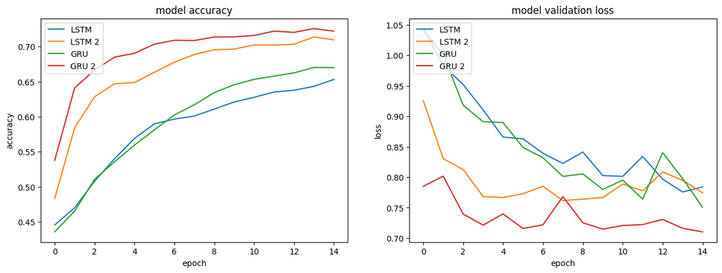

```python
plt.figure(figsize=(15,5))
plt.subplot(121)
plt.plot(lstm_history[1][0].history['accuracy'])
plt.plot(lstm2_history[0][0].history['accuracy'])
plt.plot(gru_history[2][0].history['accuracy'])
plt.plot(gru2_history[1][0].history['accuracy'])
plt.title('model accuracy')
plt.ylabel('accuracy')
plt.xlabel('epoch')
plt.legend(['LSTM', 'LSTM 2', 'GRU', 'GRU 2'], loc='upper left')

plt.subplot(122)
plt.plot(lstm_history[1][0].history['val_loss'])
plt.plot(lstm2_history[0][0].history['val_loss'])
plt.plot(gru_history[2][0].history['val_loss'])
plt.plot(gru2_history[1][0].history['val_loss'])
plt.title('model validation loss')
plt.ylabel('loss')
plt.xlabel('epoch')
plt.legend(['LSTM', 'LSTM 2', 'GRU', 'GRU 2'], loc='upper left')
plt.show()
```

When they're compared like this, the models do seem more converged than we origionally thought... We still would have benefitted from greater certainty if we ran them for a little longer, but the results already seem relatively clear.

LSTM 2 and GRU 2 seem to stand apart in terms of our evaluation criteria... Can this be seen in an ROC graphing?

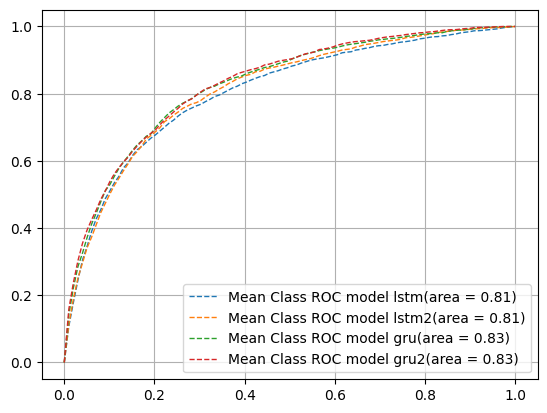

```python
from sklearn.metrics import roc_curve, auc
from scipy import interp
mean_tpr = 0.0
mean_fpr = np.linspace(0, 1, 100)
all_tpr = []
y = np.argmax(y_ohe,axis=1)

counter = 0
for model in [yhat_lstm,yhat_lstm2,yhat_gru,yhat_gru2]:
    y_hat = model[models_best[counter]]

    perclass_mean_tpr = 0.0
    roc_auc = 0
    classes = [0,1,2]
    # get the mean fpr and tpr, per class
    for j in classes:
        fpr, tpr, thresholds = roc_curve(np.argmax(y_tests[models_best[counter]],axis=1),
                                         np.array(y_hat)[:,j],pos_label=j)
        perclass_mean_tpr += interp(mean_fpr, fpr, tpr)
        perclass_mean_tpr[0] = 0.0
        roc_auc += auc(fpr, tpr)
    counter += 1
    perclass_mean_tpr /= len(classes)
    roc_auc /= len(classes)
    mean_tpr += perclass_mean_tpr
    plt.plot(mean_fpr,perclass_mean_tpr,'--',lw=1,label='Mean Class ROC model ' + str_list[counter-1] +  '(area = %0.2f)'
                   % (roc_auc))

mean_tpr /= 4
mean_auc = auc(mean_fpr, mean_tpr)
# plt.plot(mean_fpr,perclass_mean_tpr,'k-',lw=2,label='Total Mean ROC (area = %0.2f)'
#                    % (mean_auc))
plt.legend(loc='best')
plt.grid()
```

```python
print("LSTM 1 vs. LSTM 2")
conf = mt.confusion_matrix(np.argmax(yhat_lstm[models_best[0]],axis=1),np.argmax(yhat_lstm2[models_best[1]],axis=1))
print(mcnemar(conf, exact=False))
print(conf)
```

```
LSTM 1 vs. LSTM 2
pvalue      0.651896407252236
statistic   0.20351758793969849
[[164 194 267]
 [204 294 315]
 [299 438 511]]
```

There does not seem to be a difference between LSTM 1 and 2. This is pretty shocking given the difference we saw in accuracies, but it's reasonable to us that the models aren't very different in their methods. It's possible we could have added more nodes and that after longer training, the models would diverge. But for the amount we ran them they aren't disparate

```python
print("LSTM 1 vs. GRU 1")
conf = mt.confusion_matrix(np.argmax(yhat_lstm[models_best[0]],axis=1),np.argmax(yhat_gru[models_best[2]],axis=1))
print(mcnemar(conf, exact=False))
print(conf)
```

```
LSTM 1 vs. GRU 1
pvalue      0.009054784585237303
statistic   6.8119891008174385
[[134 209 282]
 [158 269 386]
 [224 393 631]]
```

LSTM1 and GRU1 are extremely different! Let's see how seperate Worst (LSTM1) and best (GRU2) are:

```python
print("LSTM 1 vs. GRU 2")
conf = mt.confusion_matrix(np.argmax(yhat_lstm[models_best[0]],axis=1),np.argmax(yhat_gru2[models_best[3]],axis=1))
print(mcnemar(conf, exact=False))
print(conf)
```

```
LSTM 1 vs. GRU 2
pvalue      0.015328955539549261
statistic   5.878260869565217
[[469  44 112]
 [ 71 582 160]
 [110 147 991]]
```

```python
print("GRU 1 vs. GRU 2")
conf = mt.confusion_matrix(np.argmax(yhat_gru[models_best[2]],axis=1),np.argmax(yhat_gru2[models_best[3]],axis=1))
print(mcnemar(conf, exact=False))
print(conf)
```

```
GRU 1 vs. GRU 2
pvalue      0.003941785051409258
statistic   8.31043956043956
[[132 154 230]
 [210 242 419]
 [308 377 614]]
```

```python
t = 4.3 /np.sqrt(3)
e = (1-np.array(scores_lstm))-(1-np.array(scores_lstm2))-(1-np.array(scores_gru))-(1-np.array(scores_gru2))
stdtot = np.std(e)
dbar = np.mean(e)
print('Range of:', dbar-t*stdtot,dbar+t*stdtot)

print('Mean errors:', np.mean(1-np.array(scores_lstm)), np.mean(1-np.array(scores_lstm2)), np.mean(1-np.array(scores_gru)), np.mean(1-np.array(scores_gru2)))


print('Model GRU2 has statistically the best performance with 95% confidence as it has the lowest error rate')
```

```
Range of: -0.6634524425117329 -0.6274385974485551
Mean errors: 0.350210970464135 0.3445023579051874 0.3361876396128071 0.3149664929262844
Model GRU2 has statistically the best performance with 95% confidence as it has the lowest error rate
```

We also know a good model when we see one. This is a purebred A1 model.

That's all the comparing we could think of. The results seem to state something relatively intuitive: more neurons is better. Also GRU is better than LSTM for this task.

## Exceptional Work (1 points total)

Fall 2022 Skip this part of the rubric; You will receive full credit for the exceptional credit.

**Yay!**